# COMPSCIX 415.2 Homework 1

## Compile and commit

At this point you may want to compile your document to see what it looks like. Click the knit button at the top of the source pane. Your doc should knit and open in a new window.

From here, change the style, text, or fix any errors in your code that show up. Use the R Markdown cheat sheet to help with this. You can find it by clicking Help -> Cheatsheets -> R Markdown Cheat Sheet.

Commit your changes with a useful comment such as “finished questions 1 and 2”.

## Extract data the tidy way

We can also extract columns in these ways:

```r
country_col <- select(WorldCities, country)
country_col <- WorldCities %>% select(country)
```

Here, `select` is a function (we’ll call it a verb in the future), which selects the column “country” from WorldCities. Remember that you can look at the help file:

`?select`

If there are multiple packages that have a `select` function, all of these will be listed and you should pick the one from package `dplyr`.

The `%>%` is a pipe operator. It works by plugging in WorldCities as the first argument in the `select` function - it is equivalent to `select(WorldCities, country)`. For example, `country_col %>% unique()` will output the unique values in `country_col` because it is equivalent to running `unique(country_col)`. These pipes will be used very often, and make your code much more readable. You can also string together multiple pipes, you just have to remember to read your code from left to right, and that is the order that your code will be run.

`first_this %>% then_this %>% then_this`

and your results will sequentially be plugged into the next function as the first argument. Example:

```r
WorldCities %>% select(region) %>% head(5)
```

| region |
| --- |
| Europe/Andorra |
| Europe/Andorra |
| Asia/Dubai |
| Asia/Dubai |
| Asia/Dubai |

[output not shown]

5 rows

This works by first running `select(WorldCities, region)` and then taking the result of that and plugging it into `head` as the first argument.

### **QUESTION 3: Can you extract and show the unique entries from the country column in WorldCities using one line of code and two %>% operators? The output will look like this:**

| country |
| --- |
| AD |
| AE |
| AF |
| AG |
| AI |
| AL |
| AM |
| AO |
| AR |

[output not shown]

9 rows

## Visualize it

Let’s get an idea of the distribution of city populations. We’ll talk about the best types of plots for distributions next week. For now, we’ll just make a basic histogram using the `ggplot` function.

Include this in your markdown and run it.

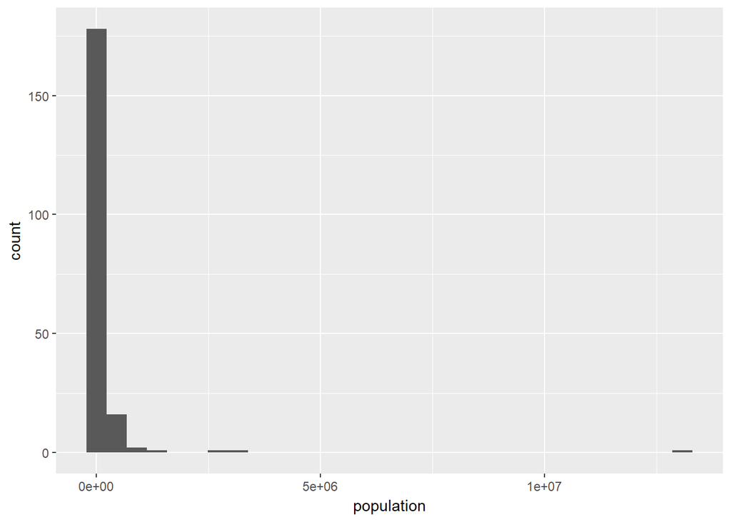

```r
WorldCities %>% ggplot(aes(x = population)) +
  geom_histogram()
```

We build plots using layers (the + sign) with `ggplot`. For instance, if we want to change the x-axis label from “population” to “City Population”, we just add another layer like this:

```r
WorldCities %>% ggplot(aes(x = population)) +
  geom_histogram() +
  xlab('City Population')
```

[output not shown]

We will get into details about this later.

### **QUESTION 4: Make one more histogram of the population and add a new x-label, a new y-label, a new title (use `ggtitle('my title')`), and change the theme of the plot using `theme_bw()`.**

# Turn in your completed assignment

Save your document and knit it. If you’re happy with it, commit your changes with the comment “finished assignment” and push your R Markdown file and your html file to Github.

You can turn in your assignment to me in one of two ways in Canvas: (1) upload your html document; or (2) type in the URL to your html file in Github.